# Midterm

Vijay Penmetsa

## Boston Housing Dataset [30 points]

The Boston Housing dataset contains information on 506 census housing tracts in the Boston area. The data is stored in the file `Boston.csv`. It contains 7 variables, `crim`, `chas`, `nox`, `room`, `dis`, `lstat` and `value`. The data description is as follows.

- `crim`: Per capita crime rate
- `chas`: Charles River (=Yes if tract bounds river; =No otherwise)
- `nox`: Nitric oxide concentration (parts per 10 million)
- `room`: Average number of rooms per house
- `dis`: Weighted distances to five Boston employment centers
- `lstat`: Percentage lower status of the population
- `value`: Median house price in the tract ($10,000s)

Our goal is to build several statistical models such that we can predict the median house price in new tracts based on information such as crime rate, pollution, and number of rooms.

```r
rm(list=ls())
```

### **Q1 [14 points]** Data Visualization and Partition

**Q1(a) [2 points]** Let’s correctly read in the data in `Boston.csv` and name it as `total_data`.

```r
## Write code solution to Q1(a) here
total_data <- read.csv("./Boston.csv", header = TRUE, stringsAsFactors = TRUE)
```

**Q1(b) [4 points]** Use an **appropriate** plot to investigate the relationship between `value` and `chas`. Does a tract that bounds Charles river have higher median house price?

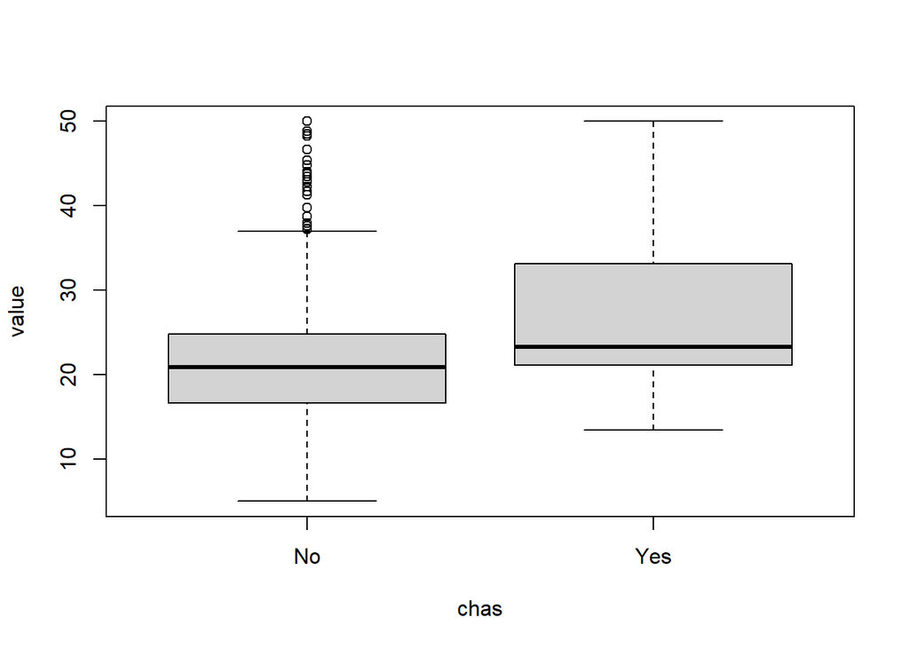

```r
## Write code solution to Q1(b) here
boxplot(value~chas, data = total_data)
```

Answer: Yes. Tract that bounds Charles river has higher median house price.

**Q1(c) [4 points]** Use a histogram to investigate if the dependent variable `value` is right-skewed. If so, further conduct a log-transformation and create a new variable named `log_value`. Make sure `log_value` is created WITHIN the data frame `total_data`.

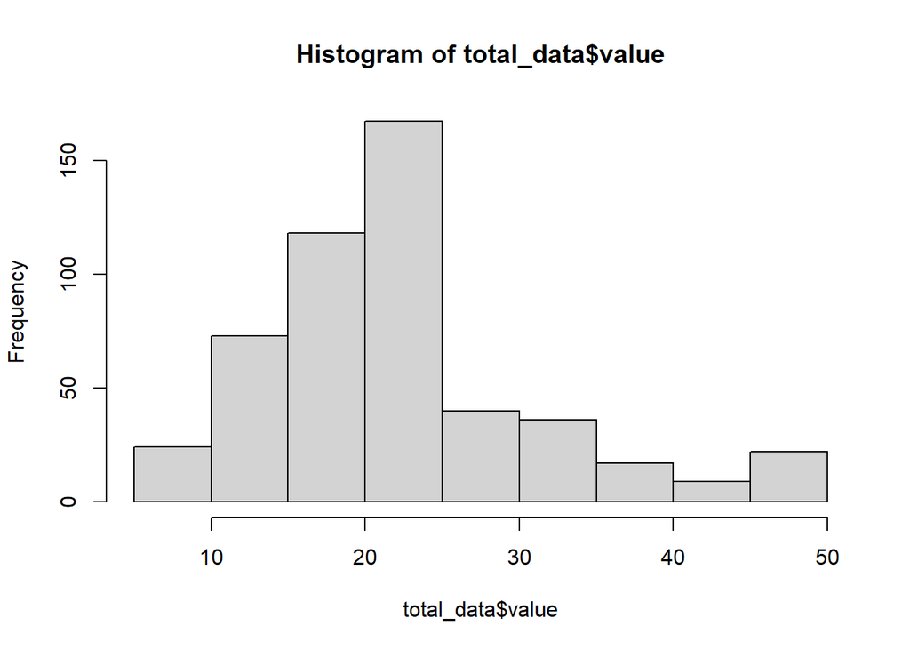

```r
## Write code solution to Q1(c) here
hist(total_data$value)
```

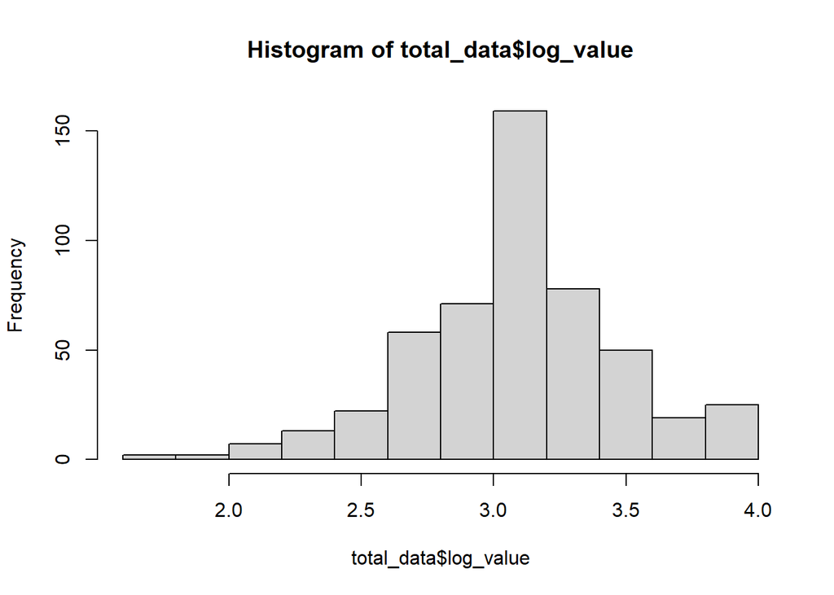

```r
total_data$log_value <- log(total_data$value + 1)

hist(total_data$log_value)
```

**Q1(d) [4 points]** Let’s partition the data in `total_data` into training **(80%)** and test data **(20%)** and store them as `R` objects `train_data` and `test_data` respectively. Use random seed **`set.seed(7)`**!

```r
## Write code solution to Q1(d) here
set.seed(7)

total_obs <- dim(total_data)[1]

train_indices <- sample(1:total_obs, 0.8 * total_obs)

train_data <- total_data[train_indices, ]
test_data <- total_data[-train_indices, ]
```

### **Q2 [6 points]** Linear Regression

**Q2(a) [4 points]** Fit a linear regression model of the **log scale** `value` w.r.t. all 6 predictors `crim`, `chas`, `nox`, `room`, `dis`, `lstat` using the **training data**, name it `lm_full`.

```r
## Write code solution to Q2(a) here
lm_full <- lm(log_value ~
                crim
              +chas
              +nox
              +room
              +dis
              +lstat,
              data = train_data)

summary(lm_full)
```

```
##
## Call:
## lm(formula = log_value ~ crim + chas + nox + room + dis + lstat,
##     data = train_data)
##
## Residuals:
##      Min       1Q   Median       3Q      Max
## -0.69768 -0.11033 -0.01830  0.09573  0.77890
##
## Coefficients:
##              Estimate Std. Error t value Pr(>|t|)
## (Intercept)  3.240890   0.162959  19.888  < 2e-16 ***
## crim        -0.009148   0.001458  -6.276 9.12e-10 ***
## chasYes      0.154057   0.040657   3.789 0.000175 ***
## nox         -0.645159   0.145878  -4.423 1.26e-05 ***
## room         0.118406   0.017825   6.643 1.02e-10 ***
## dis         -0.035752   0.007375  -4.848 1.79e-06 ***
## lstat       -0.030495   0.002145 -14.215  < 2e-16 ***
## ---
## Signif. codes:  0 '***' 0.001 '**' 0.01 '*' 0.05 '.' 0.1 ' ' 1
##
## Residual standard error: 0.1963 on 397 degrees of freedom
## Multiple R-squared:  0.7464, Adjusted R-squared:  0.7425
## F-statistic: 194.7 on 6 and 397 DF,  p-value: < 2.2e-16
```

**Q2(b) [2 points]** Look at the summary of `lm_full`. What is the $R^2$ of `lm_full`? Which predictors are statistically significant?

```r
## Write code solution to Q2(b) here
summary(lm_full)$r.sq
```

```
## [1] 0.7463743
```

Answer:  
R-Squared = 0.7464  
All 6 predictors are statistically significant. Among them, lstat is the most significant predictor.

### **Q3 [6 points]**

Fit a GAM of the **log scale** `value` w.r.t. all 6 predictors `crim`, `chas`, `nox`, `room`, `dis`, `lstat` using the **training data**, name it `gam_full`. Let’s use splines with **df=4** for all **5** numerical predictors, which include `crim`, `nox`, `room`, `dis` and `lstat`.

```r
library(gam)
## Write code solution to Q3 here
gam_full <- gam(log_value ~
                  s(crim, df = 4)
                +chas
                +s(nox, df = 4)
                +s(room, df = 4)
                +s(dis, df = 4)
                +s(lstat, df = 4),
                data = train_data)
```

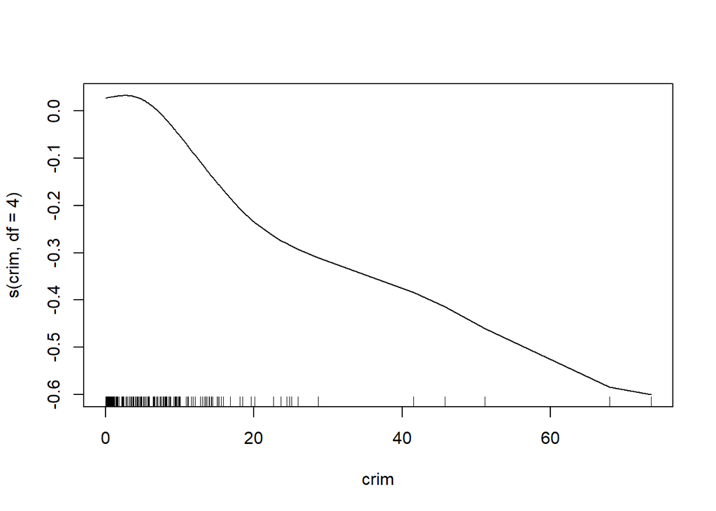

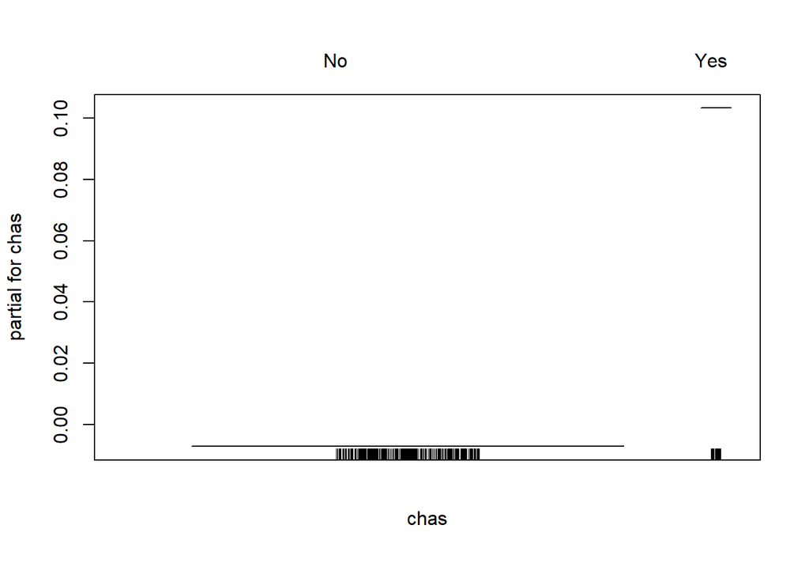

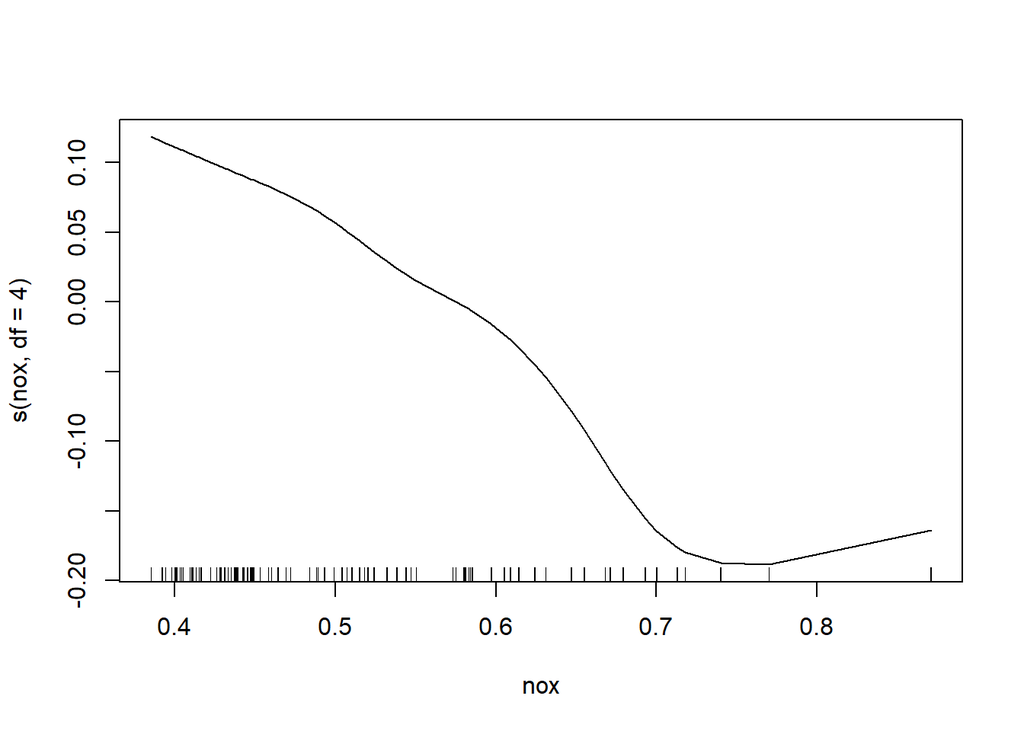

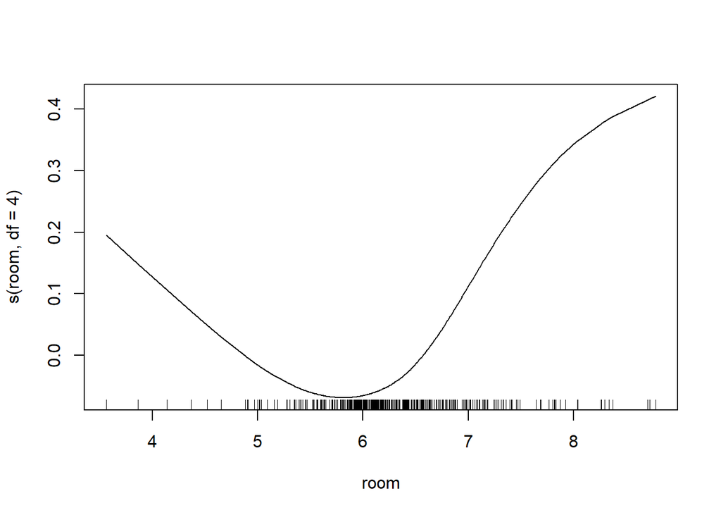

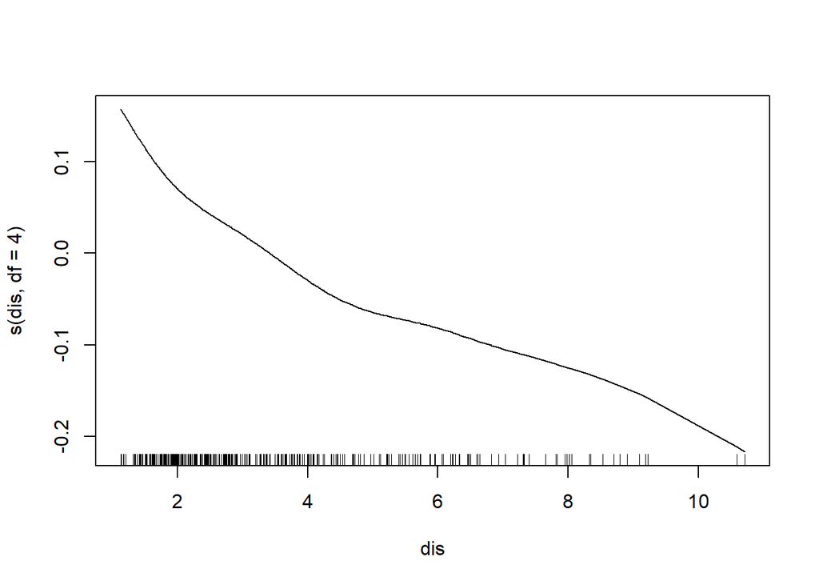

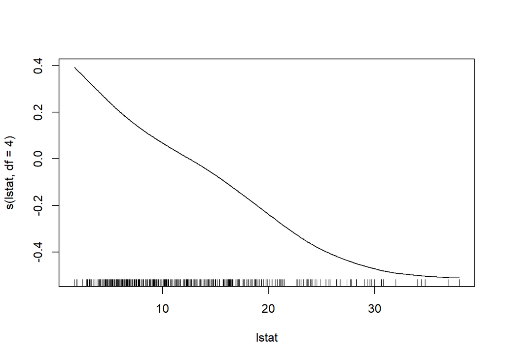

```r
plot(gam_full)
```

### **Q4 [14 points]** Neural Networks

Fit an NN of **log scale** `value` w.r.t. all 6 predictors `crim`, `chas`, `nox`, `room`, `dis`, `lstat` using the **training data**, name it `nn_full`. For the architecture of NN, let’s use one hidden layer with 4 hidden units.

**Q4(a) [4 points]** Let’s generate the **training dataset** that are needed for the estimation of NN using the function `model.matrix()` and store it in `x_train_nn`. In addition, use the `scale()` function to standardize the predictors by centering with mean and scaling with sd.

```r
## Write code solution to Q4(a) here
x_train_nn <- model.matrix(~crim+chas+nox+room+dis+lstat,
                           data = train_data)[, -1]

x_mean <- apply(x_train_nn, 2, mean)
x_sd <- apply(x_train_nn, 2, sd)

x_train_nn <- scale(x_train_nn, center = x_mean, scale = x_sd)
```

**Q4(b) [2 points]** Let’s further combine the **log scale** `value` with the standardized predictors `x_train_nn` generated in Q4(a). Don’t forget to rename the first column of the data frame as `log_value`!

```r
## Write code solution to Q4(b) here
x_train_nn <- cbind.data.frame(train_data$log_value, x_train_nn)
colnames(x_train_nn)[1] <- "log_value"
```

**Q4(c) [2 points]** Let’s generate the **test dataset** that are needed for the out-of-sample prediction evaluation of NN using the function `model.matrix` and store it in `x_test_nn`. Use the `scale()` function to standardize the predictors by centering with mean and scaling with sd as in Q4(a).

```r
## Write code solution to Q4(c) here
x_test_nn <- model.matrix(~crim+chas+nox+room+dis+lstat,
                           data = test_data)[, -1]

x_test_nn <- scale(x_test_nn, center = x_mean, scale = x_sd)
```

**Q4(d) [6 points]** Let’s fit an NN that has one hidden layers with 4 hidden units and name it `nn_full`. Make sure to use random seed **`set.seed(7)`**!

```r
## Write code solution to Q3(d) here
library(neuralnet)
set.seed(7)
nn_full <- neuralnet(log_value~crim+chasYes+nox+room+dis+lstat,
                     data=x_train_nn, hidden=c(4))
```

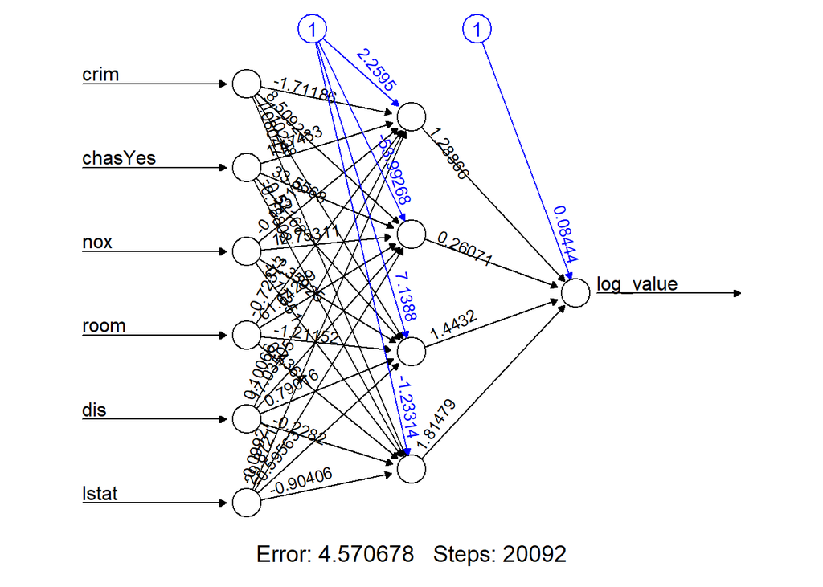

```r
plot(nn_full, rep = "best")
```

### **Q5 [10 points]** Model Evaluation (Prediction)

**Q5(a) [4 points]** Use `lm_full`, `gam_full` and `nn_full` to generate predictions for `value` on the test data and store the prediction in `lm_pred`, `gam_pred` and `nn_pred` respectively. Note that for all predictions, make sure to transform the **log-scale** prediction back to the **original scale**.

```r
## Write code solution to Q5(a) here
lm_pred <- exp(predict(lm_full, newdata=test_data)) - 1
gam_pred <- exp(predict(gam_full, newdata=test_data)) - 1
nn_pred <- exp(predict(nn_full, newdata=x_test_nn, type='response')[,1]) - 1
```

**Q5(b) [2 points]** What are the predicted median house values of the **first** tract in the test data by `lm_full`, `gam_full` and `nn_full`, respectively?

```r
## Write code solution to Q5(b) here
lm_pred[1] * 10000
```

```
##       11
## 155321.8
```

```r
gam_pred[1] * 10000
```

```
##       11
## 147461.7
```

```r
nn_pred[1] * 10000
```

```
##       11
## 158999.1
```

Answer:  
Predicted median house value of the first tract:  
lm_full = $155,321.8  
gam_full = $147,461.7  
nn_full = $158,999.1

**Q5(c) [2 points]** Use the `R` package `forecast` to evaluate the prediction performance of `lm_full`, `gam_full` and `nn_full` on the test data. What are the MAE for `lm_full`, `gam_full` and `nn_full`?

```r
library(forecast)
## Write code solution to Q5(c) here
accuracy(lm_pred, test_data$value)
```

```
##                 ME     RMSE      MAE       MPE     MAPE
## Test set 0.7702925 5.143677 3.735813 -1.215449 16.27743
```

```r
accuracy(gam_pred, test_data$value)
```

```
##                 ME    RMSE      MAE        MPE     MAPE
## Test set 0.5848851 4.14523 3.011459 -0.8298084 13.11841
```

```r
accuracy(nn_pred, test_data$value)
```

```
##                 ME    RMSE      MAE       MPE     MAPE
## Test set 0.3145513 4.06046 2.875124 -1.256505 13.03317
```

Answer:  
lm_full MAE = 3.735813  
gam_full MAE = 3.011459  
nn_full MAE = 2.875124

**Q5(d) [2 points]** Which statistical model do you prefer, `lm_full` or `gam_full` or `nn_full`? Give reasons.

Answer:  
I would prefer gam_full over lm_full and nn_full because of the prediction accuracy and simplicity. gam_full’s MAE is just about $1300 off from the MAE of nn_full. This is not a big error in terms of house prices, so we can use the simpler gam_full over nn_full.